# Seeds of Success - Diversity and impact of collections conserved in the USDA National Plant Germplasm System

Daniel Carver, Colin Khoury, Stephanie Greene, (potentially additional authors from Pullman, BLM)

June 22, 2018

**DRAFT**

- this is a working document
- at this stage the majority of the effort of the authors has been placed into developing a series of graphic/tables that alllows an exploration of the data (see results).
- The text within the document is preliminary and is expected to undergo major revisions based in part on input from outside contributors, as such much of the written content is merely an outline of what is to be expected.
- (from Colin- we need to provide a report to BLM. But for the academic paper, I personally think we should collaborate with BLM to talk about use in general including for restoration. This would be a much stronger paper, because overall the CWR and other useful plants aren’t that many)

# Abstract

Summarize the relationship between the BLM Seeds Of Success (SOS) program and the USDA ARS NPGS conservation efforts. These two organizations are collaborating on collecting, conserving, and making available for use a wide diversity of native plants occurring on public lands.

# 1 Introduction

The Seeds of Success (SOS) program was established in 2001 to facilitate the collection of native seeds. To make use of the collected materials, the program partners with land management agencies to support the re-vegetation of disturbed or degraded areas, academic and professional partners to promote and advance scientific research, and the United States Department of Agriculture (USDA) for the long term preservation of species genetic diversity.

The Seeds of Success program provides the boots on the ground effort in the collection of native seed, particularly for restoration. The program partners with the Agricultural Research Service of the USDA to store, maintain, and distribute the seeds collected. The Pullman, Washington section of the ARS is the group responsible for the initial on boarding and entering of the seeds into the Genetic Resource Inventory Network (GRIN) as well as maintaining the seeds in environments that support preservation.

- fill this out to capture aims

This article provides an overview of the diversity of plants collected by the SOS program. It then examines the conservation of this diversity within the USDA Agricultural Research Service National Plant Germplasm System (NPGS) and the distribution of samples from the NPGS to researchers. Particular focus is given to crop wild relatives which are useful as genetic resources for the improvement of cultivated plants, and other species which have been used as sources of food, medicine, forage, and other purposes.

# 2 Methods

- data acquisition
  - SOS BLM: Information regarding the SOS collection was provided as a csv file by the Seeds of Success Program National Collection Curator in June of 2018. This dataset is continually updated as more field collecting occurs. All data from the years 2017 and earlier is assumed to be correct and complete. The data collected by the SOS program contains a rich set of specific information regarding the plant from which seed is collected as well as the geographic provenance and habitat that the plant was collected from. This dataset is made available by request only and can only be used with the express permission of the BLM SOS program. **todo**
  - add information about the K13
  - add informaiton about WEP: slimmed to included plants found in the US
  - GRIN Global : The NPGS’s Germplasm Resource Information Network(GRIN-Global) provides public access to informationa regardin accessions maintained by the System. The data is publicly available online. GRIN Global data for all SOS accessions were retrieved from the database by selecting all accessions that have an action_name_code of “SOS” and stored as csvs.
  - USDA ARS Pullman office: Before assessing the datasets a meeting of individuals involved with the management of the SOS accession was held to identify the primary questions, define the process of transferring the accessions between the agencies, and understand the processing and management of the collections once they enter the NPGS. **should we reference some of the individuals from pullman here**
- data processing
  - rmarkdown : The datasets were processed, joined, and queried using the statistical programming language R. Specific libraries that were used include: plyr, tidyr, dplyr, and ggplot2. The report is compiled as an RMarkdown document to help with the reproducibility of the content as the relationship between the two organizations continues to develop. **will this stay an in house document or will it be make public.**

# 3 Results

The results are split into sections based on the primary questions we attempted to answer. We should probably highlight the questions earily in the document but for now ther are listed here.

1. How diverse is the SOS collection?
2. How many of the SOS accessions can be identified as crop wild realtives (CWR), wild utilized species (WUS), and/or economically valuable plants (i.e. listed in GRIN World Economic Plants)?
3. What is the level of representation of SOS collections within the NPGS?
4. Where are SOS accessions curated within the NPGS?
5. What is the state of SOS collections in NPGS with regard to viability?
6. Who requests SOS accessions from NPGS and for what purposes?

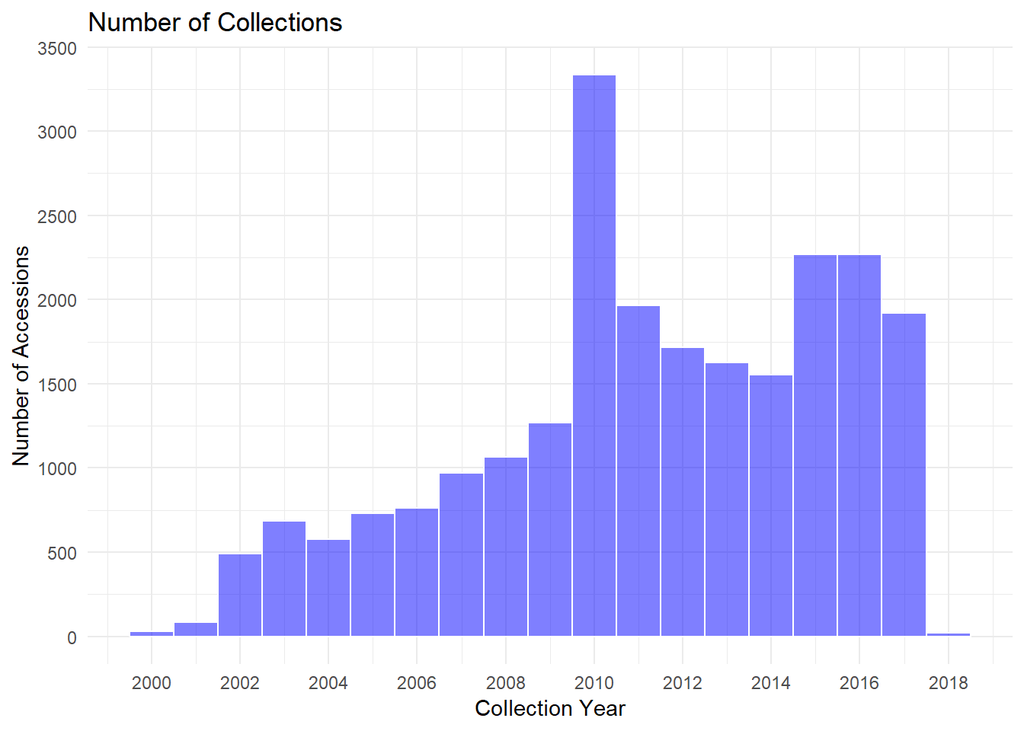

## 3.1 Diversity

|  | All Accessions | Total Number of Families | Total Number of Genera | Total Number of Taxa |
| --- | --- | --- | --- | --- |
| 1 | 23577 | 176 | 1153 | 5651 |

This Seeds of Success program since its inception has collected a total of 23577 accessions. These are comprised of 5651 unique taxa from 1153 genera from 176 plant families.

- this are interesting numbers but some knowledge on how they relate to the total number of species present in the country might make the factoids stand out some more **CK- I agree. make summary stats for national level. Check out Flora of North America as a source.**

The [Flora of North America Association](http://floranorthamerica.org/Outreach/science_outreach) provides a published reference source that provides a comrehesive and systematic account of the plant species in North American North of Mexico.

> Species descriptions are written and reviewed by experts from the systematic botanical community worldwide, based on original observations of living and herbarium specimens supplemented by a crucial review of the literature. Each treatment includes scientific and common names, taxonomic descriptions, identification keys, distribution maps, illustrations, summaries of habitat and geographic ranges, pertinent synonomy, chromosome numbers, phenology, ethnobotanical uses and toxicity, and other relevant biological information. [FNA Introduction](http://floranorthamerica.org/introduction)

As of 2018, The FNA over has idenitified over 20,100 plant species that are native or naturalizes to North America north of Mexico, this includes both vascular and bryophytes. These species fall into 268 unique familes. This implies that the SOS program has collect seed from 65.7 percent of all unique familes and approximately 13.4 of all plant species native to the US and Canada.

*right now I’m using the value for the species that does not account for subspecices or var. This can be changed based on the answer to the question below.*

**it is not clear if the plant species count is based on Unique species or unique taxa. That is are sub species and varieties included?? Hoping that some one with a familiarity with this site would know**

An accession is a sample of seeds from a single sampling location and in a single point in time. Collecting is performed, as possible, with the aim of harvesting enough seeds for short term storage, long term preservation, and for distribution.

Out of the 176 families collected half of the total accessions collected come from just 5 families. These are among the most widespread and diverse plant families in the USA.

| Family | Total Number of Accessions |
| --- | --- |
| ASTERACEAE | 5303 |
| POACEAE | 4522 |
| CYPERACEAE | 1165 |
| FABACEAE | 1122 |
| SCROPHULARIACEAE | 1027 |
| ROSACEAE | 977 |
| CHENOPODIACEAE | 614 |
| APIACEAE | 585 |
| POLYGONACEAE | 582 |
| ONAGRACEAE | 434 |

[output cut: 166 more lines]

| GENUS | n |
| --- | --- |
| CAREX | 664 |
| POA | 512 |
| ACHNATHERUM | 510 |
| ERIOGONUM | 479 |
| PENSTEMON | 449 |
| ARTEMISIA | 423 |
| ELYMUS | 407 |
| ATRIPLEX | 379 |
| BOUTELOUA | 378 |
| JUNCUS | 316 |

[output cut: 1143 more lines]

This table shows the number of accession assocatied with the genera of all samples within the SOS data .

- It would be good to know how collections are prioritized (for collecting) by SOS. Are they looking for certain species or its is rather random? **DC I agree, this is probably best answered by a BLM representative**

## 3.2 Crop wild relatives, wild utilized species, and economic plants

- add some background on value of CWR **dc- todo**

Crop wild relatives are define in Maxted et al 2006 as; > A crop wild relative is a wild plant taxon that has an indirect use derived from its relatively close genetic relationship to a crop; this relationship is defined in terms of the CWR belonging to Gene Pools 1 or 2, or taxon groups 1 to 4 of the crop.

This defination is most commonly applied to species that support are food and agricultural systems it can be extened to incorporate species that are harvested for economic or cultural purposes such as ornamentals, medicial uses, and foresty. (Maxted et al 2006). These CWR contain a genictic diversity which has been used to improvepest and desease resistance, tolerance to abioticstress, inceased yield, novel cytoplasms, and quality traits to multiple major crop species.(Khoury et al 2013) Yet the limiting factor in the utilizaiton of CWR is the collection, preservation, and accessability of genetic information for research scientist (Harlan, 1976). While this statement was made in 1976 recent work has illistrated that is still a primary matter of concern. (FAO, 2010: Fowler and Hodgekin, 2004).

A recent inventory of U.S. crop wild relatives (Khoury et al. 2013) recognized 2500 taxa from 160 genera and 56 plant families. Of these, around 300 native species were prioritized as potentially highly useful relatives of important food crops. These include the wild cousins of crops that were domesticated by indigenous peoples in the United States, such as sunflower and squash, as well as more recent domesticates, such as blueberry, cranberry, raspberry, blackberry, and pecan. Other priority species include the northernmost relatives of Mesoamerican crops such as corn, bean, chili pepper, and cotton, as well as relatives of temperate crops first domesticated in Europe and Asia, such as onion, grape, apple, hops and walnut. If properly collected, conserved, and made accessible to crop scientists, these crop wild relatives will constitute an extremely diverse portfolio supporting present and future crop improvement efforts.

- expand upon the k13 data source a bit to explain why we are using it. **dc- todo** We utilized the K13 dataset because is was generated to be the “a primary step in the the process toward a national stategy for the conservation of CWRs”. The data sets makes an important distinstion between CWR and Wild Utilized Species(WUS. CWR are considered to be species that can directly be used for crop breeding. WUS are define by those that can be used for food, forage, medicine, herb, ornamental, and/or environmental restoration purposes. This extra level of distinction provides an import distinction regarding the intented use of the species. This dataset also provides a priority ranking system while allows for the identificantion of which species could have the greatest potential of crop genetic research. These details make this an ideal dataset for the interpretation of the true effect the SOS collections are having on the preservation of genetic resources.
- add a bit about the various economic use categories defined by GRIN WEP and how the db was developed. Reference: Wiersema, J., León, B., 2013. World Economic Plants: A Standard Reference, Second ed. CRC Press. Taylor & Francis Group. Interactive database available online at chttps://npgsweb.ars-grin.gov/gringlobal/taxon/taxonomysearcheco.aspx **dc- todo**

The World Econmic Plants dataset is derived from the second edition of World Economic Plants: A Standard Reference (Wiersema, J., León, B., 2013.). This book is acts as a catalog of economic plants, maintaing a standard scientific names, common names, economic impacts, and geographic distribution. The book contains 312 families and 3,585 genera. Economic impacts are split into 16 primary classes and 113 subclasses. It is important to not that of the 16 primary classes 3 are mostly negitive in there ecomonic impacts. These economic classes have been incorperate by the [GRIN economic plant database](https://npgsweb.ars-grin.gov/gringlobal/taxon/taxonomysearcheco.aspx).

- add genus by accession - CWR WUS WEP top 20 or 50 chart/table **dc- todo**
- what does this look like
- joined dataset, but not unique
- arrange them, select name, just show name

This study is using dataset complied by Khoury et al 2013 and Wiersema and Leon 2013 to identify species that are considered crop wild relatives (CWR) and/or wild utilized species (WUS) (Khoury et al. 2013), or economic plants (WEP). The chart below is defining the primary acronyms that are used in the remainder of this document

| Acronym | Meaning |
| --- | --- |
| SOS | Seeds of Success |
| GRIN | Germplasm Resource Information Network |
| NLGRP | National Laboratory Genetic Resource Presevation |
| WUS | Wild Utilized Species |
| K13 | Khoury et al 2013 |
| CWR | Crop Wild Relative |
| WEP | Economic Plant |

```r
### attempt to make a join between sos and the
View(K13Data)
K13genusCWR <- K13Data %>%
  filter(Type == "CWR") %>%
  distinct(Genus) %>%
  lapply(toupper) %>%
  as.data.frame()

K13genusCWR
```

| Genus |
| --- |
| ABUTILON |
| ACER |
| AEGILOPS |
| AGAVE |
| AGROPYRON |
| AGROSTIS |
| ALLIUM |
| ALOPECURUS |
| AMARANTHUS |
| ANDROPOGON |

[output cut: 150 more lines]

```r
K13genusWUS <- K13Data %>%
  filter(Type == "WUS") %>%
  distinct(Genus) %>%
  lapply(toupper) %>%
  as.data.frame()
K13genusWUS
```

| Genus |
| --- |
| ABIES |
| ABRONIA |
| ACACIA |
| ACAMPTOPAPPUS |
| ACER |
| ACHILLEA |
| ACHLYS |
| ACHNATHERUM |
| ACOELORRHAPHE |
| ACONITUM |

[output cut: 823 more lines]

```r
wepLocalGenus <- tbl_df(read.csv("H:\\SOS_Project\\analysisData\\Distributions&NativityOfSpeciesWithEconomicUses.csv")) %>%
  filter(country_code == 'USA') %>%
  separate(name, c('Genus','species'))%>%
  distinct(Genus)%>%
  lapply(toupper) %>%
  as.data.frame()
sosGeneraCount <- sosData %>%
  dplyr::rename(Genus = GENUS)%>%
  group_by(Genus) %>%
  dplyr::summarise(count = n())
sosGeneraCount
```

| Genus | count |
| --- | --- |
|  | 7 |
| ABIES | 2 |
| ABRONIA | 19 |
| ABUTILON | 2 |
| ACACIA | 18 |
| ACAENA | 1 |
| ACALYPHA | 6 |
| ACAMPTOPAPPUS | 26 |
| ACER | 20 |
| ACHILLEA | 102 |

[output cut: 1143 more lines]

```r
sosCWRgenus <- right_join(sosGeneraCount,K13genusCWR, by="Genus" )%>%
  arrange(desc(count)) %>%
  slice(1:20) %>%
  select(Genus) %>%
  dplyr::rename(CWR = Genus)
sosWUSgenus <- right_join(sosGeneraCount,K13genusWUS, by="Genus" )%>%
  arrange(desc(count)) %>%
  slice(1:20) %>%
  select(Genus) %>%
  dplyr::rename(WUS = Genus)
sosWEPgenus <- right_join(sosGeneraCount,wepLocalGenus, by="Genus" )%>%
  arrange(desc(count)) %>%
  slice(1:20) %>%
  select(Genus) %>%
  dplyr::rename(WEP = Genus)
top20 <-  cbind(sosWUSgenus, sosCWRgenus, sosWEPgenus)

top20
```

| WUS | CWR | WEP |
| --- | --- | --- |
| CAREX | POA | CAREX |
| ACHNATHERUM | PENSTEMON | POA |
| ERIOGONUM | ARTEMISIA | ACHNATHERUM |
| BOUTELOUA | ELYMUS | ERIOGONUM |
| JUNCUS | ATRIPLEX | PENSTEMON |
| LOMATIUM | ASTRAGALUS | ARTEMISIA |
| SOLIDAGO | ALLIUM | ELYMUS |
| ERIGERON | LUPINUS | ATRIPLEX |
| SPHAERALCEA | LEYMUS | BOUTELOUA |
| SPOROBOLUS | PANICUM | JUNCUS |

[output cut: 10 more lines]

The table below illustrates the total number of genera and taxa listed in the datasets. The SOS, K13, and WEP data sets reference plants found in the USA.

|  | Total Number of Genera | Total Number of Species |
| --- | --- | --- |
| SOS | 1153 | 2693 |
| CWR in K13 | 160 | 2488 |
| WUS in K13 | 833 | 2101 |
| WEP | 1297 | 3655 |

The following table displays the number and proportion of SOS accessions that could be classified by Khoury et al. 2013 as CWR and/or WUS, or by Wiersema and Leon 2013 as a WEP.**CK - list CWR then WUS then WEP, always in that order. Also I think this table would be better horizontal rather than vertical**

[output not shown]

[output cut: 1 more lines]

## 3.3 Conservation

The following table displays the diversity of SOS accessions that are currently maintained within the NPGS.

### 3.3.1 Accessions Stored Within the ARS System

The difference in the total number of accessions collected by SOS and the number of accessions recorded in GRIN is significant. Part of this can be explained by a potential backlog of samples within the ARS and a lag in delivery time between collection and distribution. It generally takes a year from when the seeds are collect to when they are received by the ARS. There is a lagtime between collecting seed and entrance into the system due to the work of processing seed and associated data. Not all SOS accesions make it into the NPGS (why? insufficient seed?)

### 3.3.2 Accession Maintained at NLGRP for Long Term Backup

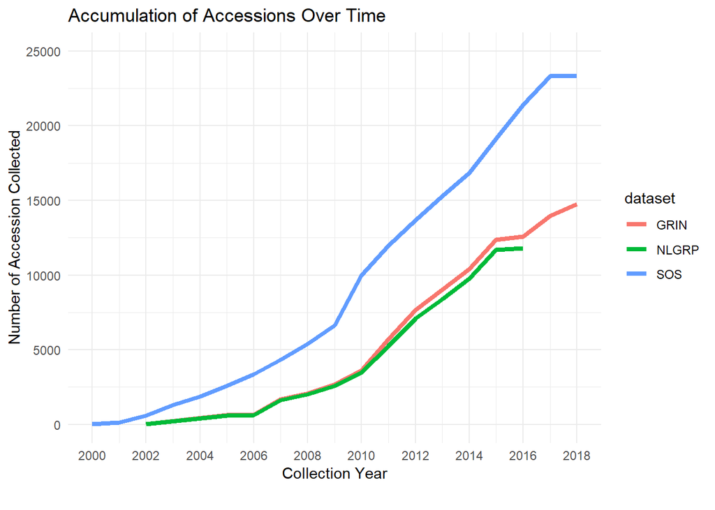

This illustrates that the rate of accumulation between the three groups flucuates a bit over time. The drop in number of samples incorporated into GRIN and NLGRP in the more resent years is due in part to the time lag between data collecting, seed processing, and storage.

[output not shown]

[output cut: 1 more lines]

## 3.4 Where are SOS accessions Maintained in the NPGS?

The challenge of coordinating the preservation of these seeds is seen in part by how my samples become orphaned within the system, lacking a curator specialized in the pertinent genus or species. Orphaned accesions are those which do not fit into any of the existing collections. Orphaned accessions continue to be held at Pullman (W6) but without a formal curator. Note the Pullman quantities in the table include both curator and non curated accessions.

```r
# call in sosAccessions: summaries by maintaince site or owned by ***check with Colin or Renee on this one***
# produce a table showing number of successions and proportion of total


#group by location and derive number of taxon
sosAccTaxa <- grinData %>%
  group_by(Accession.Prefix) %>%
  dplyr::summarise(uniqueNumber = n_distinct(Taxon)) %>%
  dplyr::rename(Facility = "Accession.Prefix", UniqueTaxa = "uniqueNumber" )

library(plyr)
# subet columns needed.
sosOwner <- count(grinData$Accession.Prefix)%>%
  arrange(desc(freq))%>%
  dplyr::rename(Facility = x, NumberOfAccessions = freq)%>%
  mutate(FacilityName = c("Western Regional Plant Introduction Station, Washington", "Ornamental Plant Germplasm Center, Ohio", "National Animal Disease Center, Iowa",
                          "Plant Introduction Research, Iowa", "NSL unknown" , "Plant Genetic Resources Conservation Unit, Georgia", "SARU unknown Plants from alaska??", "Missing Data"))

#join the two datasets
sosOwner2 <- left_join(sosOwner, sosAccTaxa, by='Facility', type='left', match='all') %>%
  dplyr::rename(FacilityAcronym = "Facility") %>%
  select(FacilityName, FacilityAcronym, NumberOfAccessions, UniqueTaxa)

sosOwner2
```

| FacilityName | FacilityAcronym | NumberOfAccessions | UniqueTaxa |
| --- | --- | --- | --- |
| Western Regional Plant Introduction Station, Washington | W6 | 11958 | 3257 |
| Ornamental Plant Germplasm Center, Ohio | OPGC | 1179 | 549 |
| National Animal Disease Center, Iowa | Ames | 766 | 269 |
| Plant Introduction Research, Iowa | PI | 404 | 181 |
| NSL unknown | NSL | 252 | 237 |
| Plant Genetic Resources Conservation Unit, Georgia | Grif | 196 | 65 |
| SARU unknown Plants from alaska?? | SARU | 7 | 6 |
| Missing Data | NA | 5 | 4 |

The majority of the SOS collection is maintained by the ARS in Pullman, Washington (W6). This is where the native plant collection is based. Accession that are maintained at other locations are there due to the request of other curators. The are accessions that are very unlikely to be orphaned. It is difficult to determine from data alone how many of the accession at W6 an being actively stored but not regenerated.

## 3.5 Viability of SOS seeds

Collection and storage are only part of the story. Germination and the ability to grow out the plant to collect new seeds is a large part of what the nPGS does. Often little is known about the conditions required to germinate the seeds.

An experiment was developed and performed by Annette Miller at the NLGRP. Annette tested the viability of seeds to germinate for 794 unique genera. This accounts for 68.86 percent of all the genera collected by the SOS program. The data generated by this study illustrates what to expect when working with these plants in the future. The table below shows that percentage of seeds that were tested that were successfully geminated. The histogram groups those into viability categories.

```r
colnames(viability) <- c('Genus', 'percentViable' )
arrange(viability, desc(percentViable))
```

| Genus | percentViable |
| --- | --- |
| Cosmos | 100.00000 |
| Moehringia | 100.00000 |
| Robinia | 100.00000 |
| Zephyranthes | 100.00000 |
| Phaseolus | 99.50000 |
| Convolvulus | 99.00000 |
| Alopecurus | 98.00000 |
| Houstonia | 98.00000 |
| Phryma | 98.00000 |
| Selenia | 98.00000 |

[output cut: 784 more lines]

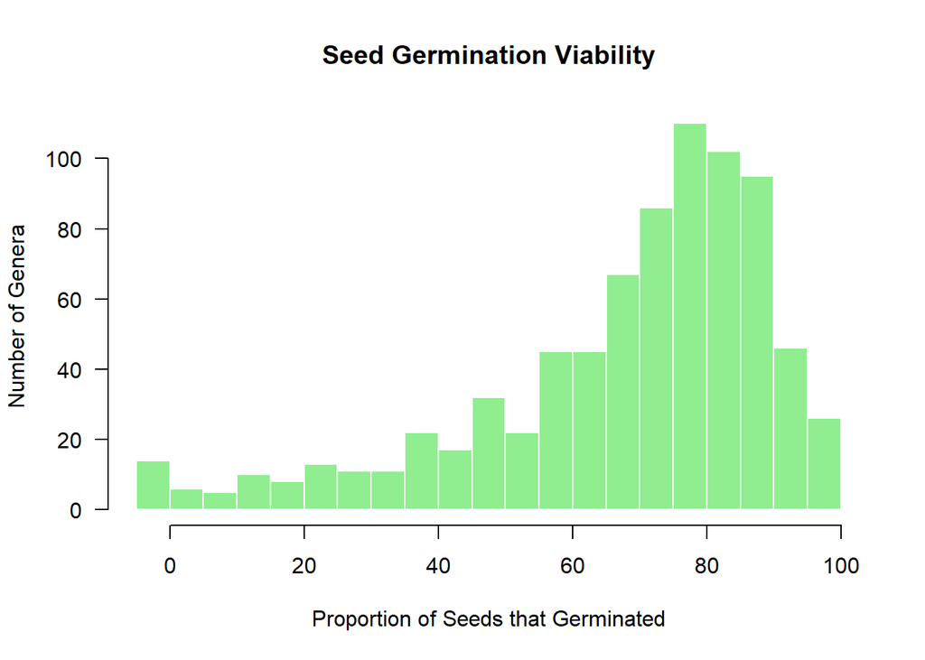

This distribution shows that the majority of the species collected by the SOS can be germinated given the current level of understanding. Species that had a very low germination success rate will require more research to understand what are the necessary conditions to promote successful germination. Until those methods are understood it may not be possible to maintain the population indefinitely.

## 3.6 Distribution of SOS Materials from the NPGS

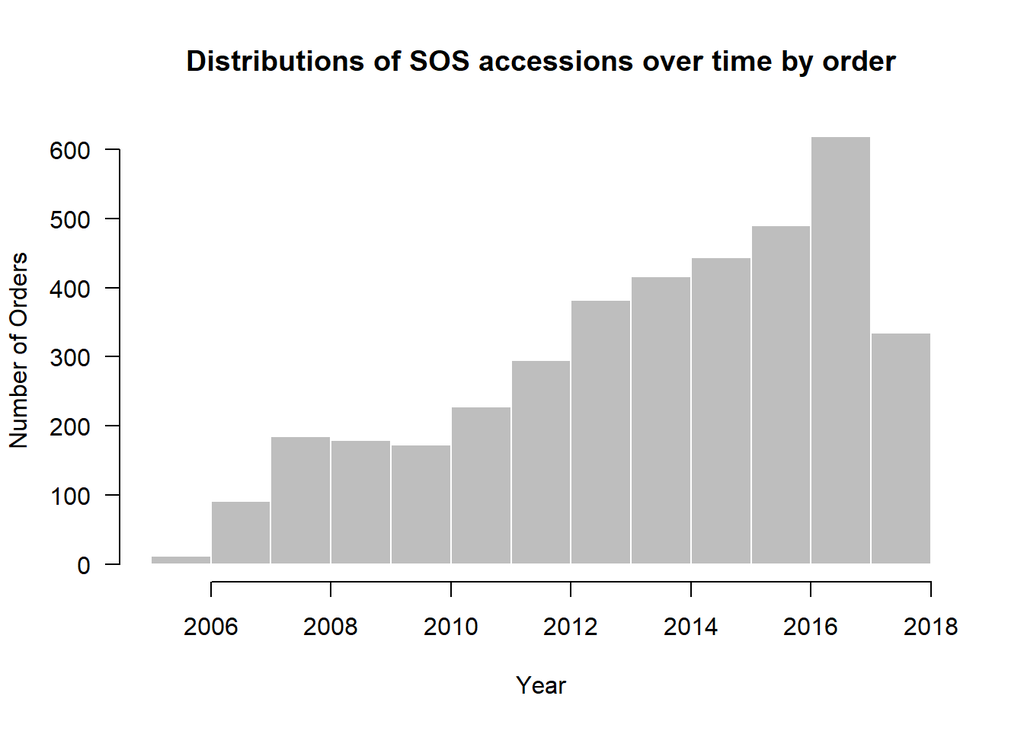

The NPGS stores and distributes to researchers accesions that collected by SOS. Seeds are distributed for a number of reasons including academic research studies and educational demonstrations. Many of the distributions take place within the ARS when seeds are sent to and from various seed labs (CK - ???). The distribution of seeds is end user driven and a result the volume of seeds transferred fluctuates over time.

| Reason for Distribution | Individual Shipments |
| --- | --- |
| NA | 2466 |
| Research | 808 |
| Education | 408 |
| Other | 103 |
| Home Gardening | 41 |

It is unclear if the reason for distribution column within the grin global accession request process is a fill in the blank or drop down. There is a lot of variablility within the supplied answers. **Should requestors be able to enter their own reason for a request** **DC most of that was sloppy data coming in, I did a bit of filtering to remove the request that are not standardized.**

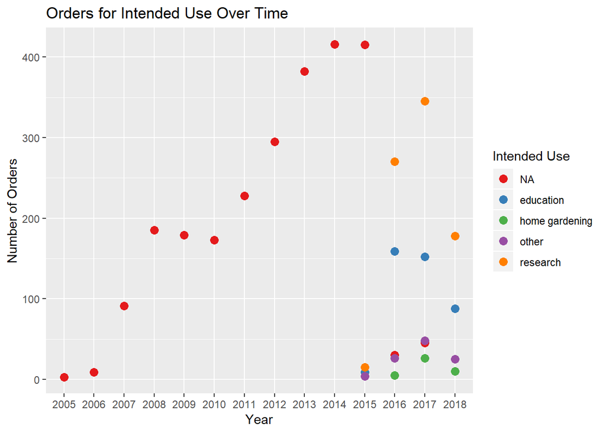

If we take a look at the deliveries over time we can see there is some distinct variability over time. The NA variable is present because before 2015 the reason for distribution was not recorded.

**Need to ask renee to reproduce this dataset, something is wrong. there are more genera present in the distribution data then there are in NLGRP holdings**

| Entity Receiving Seeds | Number Of Genera Distributed | Samples Distributed |
| --- | --- | --- |
| U.S. state agencies and all universities | 514 | 4966 |
| U.S. individual no affiliation | 476 | 6384 |
| Foreign non-commercial organization | 297 | 2180 |
| U.S. commercial company | 288 | 1647 |
| U.S. non-profit organizations | 261 | 1360 |
| Foreign commercial company | 99 | 847 |
| U.S. federal agency (not AID or ARS) | 87 | 501 |
| Foreign individual no affiliation | 48 | 125 |
| Foreign genebank/genetic resources unit | 33 | 68 |

Table illustrating the total number of samples sent, including per unique genus. There has been a total of 18078 seeds and or packets distributed by the ARS that were collected by the SOS program. There are many more sample devilered then orders made because a single order request could contain mutlple samples.

**CK- these numbers dont align with the figure above**

**DC - the difference in numbers is due to the fact that a single order can contain multiple samples. There have been 4,018 order that contianed 18,078 unique samples.**

This will be a good question for the other individuals more familiar with the delivery process.

There are a total of 18078 samples that have been distributed by the NPGS. Of that 16802, are considered to be either CWR or WUS and 16037 are consider to be WEP. This is representing 465 and 447 unique genera respectively.

This chart shows the number of times an order was placed for a specific accession.

| Accession | Accessions Pulled From |
| --- | --- |
| NA | 1793 |
| W6 27227 | 32 |
| Ames 29888 | 27 |
| W6 26755 | 26 |
| W6 45791 | 23 |
| PI 675069 | 21 |
| W6 30326 | 21 |
| W6 32535 | 21 |
| W6 32664 | 21 |
| W6 26980 | 19 |

[output cut: 4141 more lines]

This chart shows the number of times an order was place for a specific accession.

| Taxon | Total Delivered | Total Packets?? |
| --- | --- | --- |
| NA | 1627 | 311 |
| Achnatherum hymenoides | 246 | 299 |
| Salvia columbariae | 152 | 310 |
| Achillea millefolium | 105 | 304 |
| Poa secunda | 88 | 299 |
| Koeleria macrantha | 83 | 285 |
| Asclepias speciosa | 71 | 298 |
| Linum lewisii | 71 | 260 |
| Elymus elymoides | 70 | 268 |
| Poa fendleriana | 69 | 244 |

[output cut: 1875 more lines]

This chart shows the number of times a specific taxon was has been delivered. These deliveries could include multiple accessions.

| Taxon | Total Taxon | Total Delivered | Total Packets?? |
| --- | --- | --- | --- |
| Young, Carolyn, Noble Research Institute, 2510 Sam Noble Parkway, Ardmore, Oklahoma, United States | 17 | 196 | 220 |
| Roybal, Carla, Northern Arizona University, Biology Department, 617 S Beaver St, Flagstaff, Arizona, United States | 15 | 162 | 69 |
| Van Herwijnen, Zeger, Rijk Zwaan Breeding, burg crezeelaan 40, De Lier, South Holland, Netherlands | 65 | 142 | 307 |
| Cramer, Chris, New Mexico State Univ., N127 Skeen Hall, Las Cruces, New Mexico, United States | 80 | 138 | 258 |
| Ford, Tim, IPPFBE, Inc., 400 North 1000 East, Hyde Park, Utah, United States | 5 | 127 | 280 |
| Rodriguez, Jessica, , 15595 Tetley Street, Hacienda Heights, California, United States | 124 | 126 | 299 |
| Arnow, Jonathan, Alpine Distributors, 57 Home Fair Drive, Farfield, Connecticut, United States | 88 | 114 | 299 |
| Rhode, David, Desert Research Institute, 2215 Raggio Parkway, Reno, Nevada, United States | 111 | 112 | 209 |
| Kolano, Bozena, University of Silesia, Department of Plant Anatomy and Cytology, Silesia, Katowice, Poland | 26 | 101 | 299 |
| Tucker, Arthur O., Delaware State University, Department of Agriculture & Natural Resources, Dover, Delaware, United States | 84 | 85 | 188 |

[output cut: 2329 more lines]

This graphic shows which usert is receiving the greatest diversity of taxa. **again the question of the base unit is here. It would seem that a packet is the smallest unit counted but I do not know**

# 4 to Do

- Investigate reasons for use- narrative description in GRIN Global
- feedback on existing process

# 5 Discussion

- there is a lot of room for narrative and exploration of these results. Collaboration with individuals more involved in the processing of these accession need to be pulled in to provide opinions and highlight significance of results per each section